# Linear Model

Abel Jacobo Perez

10/19/2021

## Introduction

Then form three regression models; Model1 is SIMS~ARM, Model2 is SIMS~GRIP, and Model3 is SIMS~ARM+GRIP. For each model find a 95% prediction interval of SIMS given a value of 94 for GRIP and 88 for ARM. Compare Model1 with Model3 using anova. Write it up in a markdown document, push the project up to your github account and submit it back to canvas as link.

## SIMS~ARM Regression

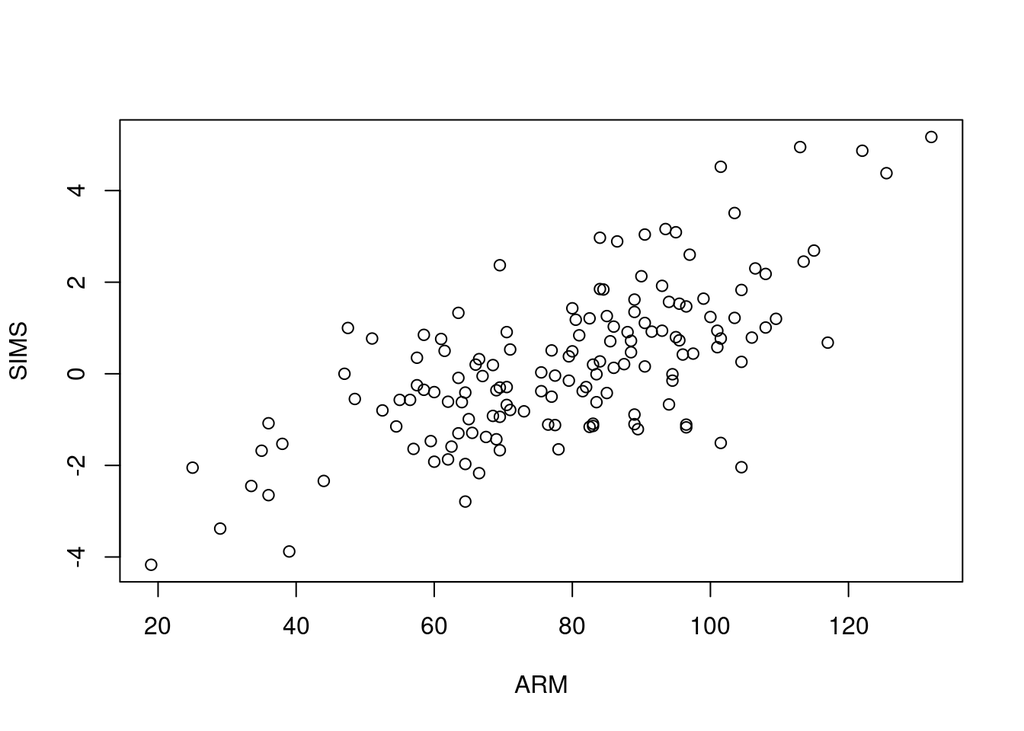

```r
plot(SIMS~ARM,data=data)
```

This is a generic scatter plot of SIMS vs ARM

```r
cor(SIMS~ARM,data=data)
```

```
## [1] 0.6860073
```

the greater the pounds of arm force(ARM), the greater the simulation(SIMS)

```r
model.1 <- lm(SIMS~ARM,data=data)
summary.lm(model.1)
```

```
##
## Call:
## lm(formula = SIMS ~ ARM, data = data)
##
## Residuals:
##     Min      1Q  Median      3Q     Max
## -3.6467 -0.7502 -0.0285  0.6875  3.0770
##
## Coefficients:
##              Estimate Std. Error t value Pr(>|t|)
## (Intercept) -4.095160   0.391745  -10.45   <2e-16 ***
## ARM          0.054563   0.004806   11.35   <2e-16 ***
## ---
## Signif. codes:  0 '***' 0.001 '**' 0.01 '*' 0.05 '.' 0.1 ' ' 1
##
## Residual standard error: 1.226 on 145 degrees of freedom
## Multiple R-squared:  0.4706, Adjusted R-squared:  0.467
## F-statistic: 128.9 on 1 and 145 DF,  p-value: < 2.2e-16
```

The equation is SIMS= -4.095160 + 0.054563 * ARM

```r
basicNN <- ggplot(data,aes(y=SIMS,x=ARM))
```

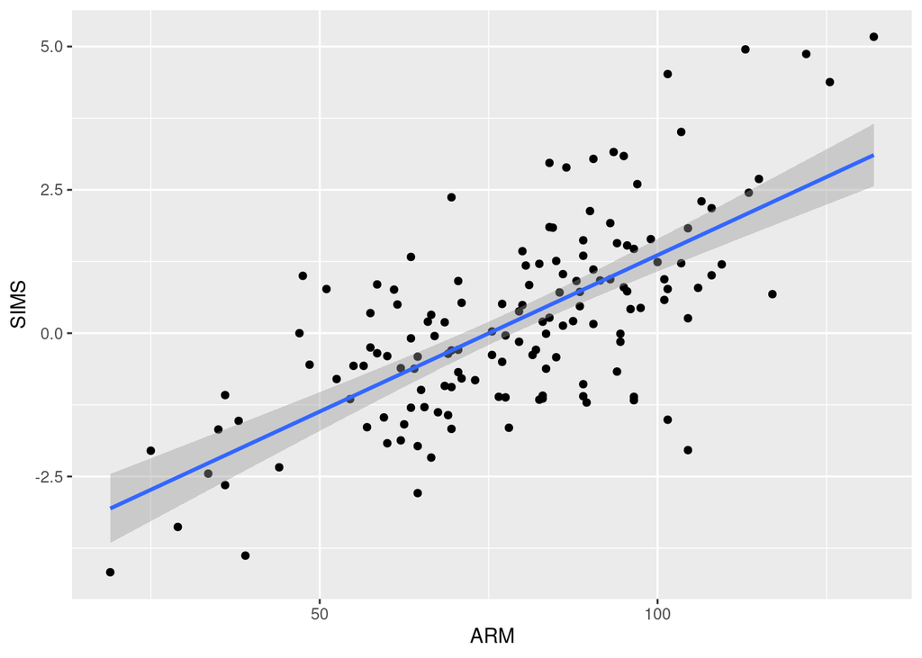

```r
basicNN + geom_point() + geom_smooth(method=lm)
```

This scatter plot shows the blue line which is best linear fit to predict what an average sim response would be for any ARM strength.

The shaded part is the uncertainty of the blue line itself.

Shows all of the data points of each individual score and corresponding arm strength.

```r
newData=data.frame(GRIP=94,ARM=88)
predict.lm(model.1,newData,interval="prediction")
```

```
##         fit       lwr      upr
## 1 0.7063836 -1.726209 3.138977
```

the lwr and upr are the 95% confidence intervals for predicted SIMS score when the ARM is 88.

## SIMS~GRIP REGRESSION

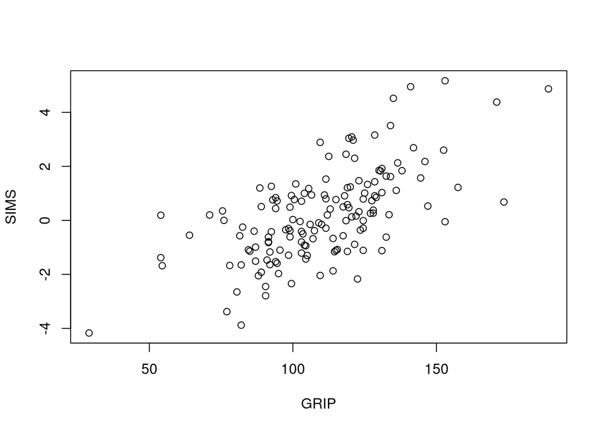

```r
plot(SIMS~GRIP,data=data)
```

This is a generic scatter plot of SIMS vs GRIP

```r
cor(SIMS~GRIP,data=data)
```

```
## [1] 0.6398458
```

the greater the pounds of GRIP force(GRIP), the greater the simulation(SIMS)

```r
model.2 <- lm(SIMS~GRIP,data=data)
summary.lm(model.2)
```

```
##
## Call:
## lm(formula = SIMS ~ GRIP, data = data)
##
## Residuals:
##     Min      1Q  Median      3Q     Max
## -2.9295 -0.8708 -0.1219  0.8039  3.3494
##
## Coefficients:
##              Estimate Std. Error t value Pr(>|t|)
## (Intercept) -4.809675   0.511141   -9.41   <2e-16 ***
## GRIP         0.045463   0.004535   10.03   <2e-16 ***
## ---
## Signif. codes:  0 '***' 0.001 '**' 0.01 '*' 0.05 '.' 0.1 ' ' 1
##
## Residual standard error: 1.295 on 145 degrees of freedom
## Multiple R-squared:  0.4094, Adjusted R-squared:  0.4053
## F-statistic: 100.5 on 1 and 145 DF,  p-value: < 2.2e-16
```

The equation is SIMS= -4.809675 + 0.045463 * GRIP

```r
basicNN <- ggplot(data,aes(y=SIMS,x=GRIP))
```

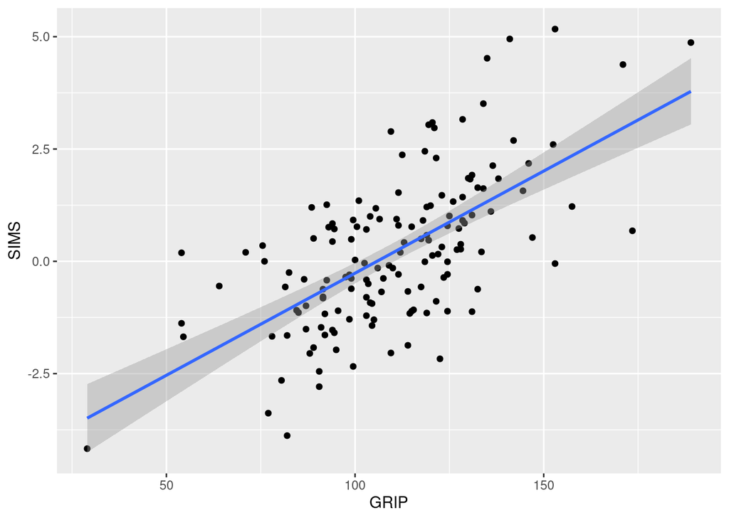

```r
basicNN + geom_point() + geom_smooth(method=lm)
```

This scatter plot shows the blue line which is best linear fit to predict what an average sim response would be for any GRIP strength.

The shaded part is the uncertainty of the blue line itself.

Shows all of the data points of each individual score and corresponding GRIP strength.

```r
newData=data.frame(GRIP=94,ARM=88)
predict.lm(model.2,newData,interval="prediction")
```

```
##          fit       lwr      upr
## 1 -0.5361543 -3.107961 2.035652
```

fit is the predicted SIMS score when you have an GRIP strength of 94.

the lwr and upr are the 95% confidence intervals for predicted SIMS score when the GRIP score is 94.

Comparing the two models, model1 and model2,

model1(SIMS~ARM)has a slightly lower Residual standered error score of 1.226 while model2(SIMS~GRIP) scored at 1.295

model1(SIMS~ARM) has a higher adjusted r squared score of 0.467 while model2(SIMS~GRIP) scored a lower 0.4053

model1 appears to be slightly better model because it has a lower Residual standard error score then model1 and also has a higher adjusted R square score than model2 as well.

## SIMS~ARM+GRIP

```r
model.3 <- lm(SIMS~ARM + GRIP,data=data)
summary.lm(model.3)
```

```
##
## Call:
## lm(formula = SIMS ~ ARM + GRIP, data = data)
##
## Residuals:
##     Min      1Q  Median      3Q     Max
## -3.1846 -0.7380 -0.0641  0.7394  2.8634
##
## Coefficients:
##              Estimate Std. Error t value Pr(>|t|)
## (Intercept) -5.433871   0.461815 -11.766  < 2e-16 ***
## ARM          0.037311   0.005774   6.462 1.50e-09 ***
## GRIP         0.024470   0.005158   4.744 4.99e-06 ***
## ---
## Signif. codes:  0 '***' 0.001 '**' 0.01 '*' 0.05 '.' 0.1 ' ' 1
##
## Residual standard error: 1.144 on 144 degrees of freedom
## Multiple R-squared:  0.5422, Adjusted R-squared:  0.5358
## F-statistic: 85.26 on 2 and 144 DF,  p-value: < 2.2e-16
```

model3 appears to be the better model because the adjusted R squared score than model1 or model2, and also scored lower in the Residual standard error than model1 or 2

```r
cor(SIMS~ARM + GRIP,data=data)
```

```
## [1] 0.7326545
```

## prediction

```r
newData=data.frame(GRIP=94,ARM=88)
predict.lm(model.3,newData,interval="prediction")
```

```
##         fit       lwr      upr
## 1 0.1496476 -2.132373 2.431668
```

fit is the predicted SIMS score when you have an GRIP strength of 94 and an ARM strength of 88.

the lwr and upr are the 95% confidence intervals for predicted SIMS score when the GRIP score is 94 and and ARM strength of 88.

## Inferential test

This is the inferential test to compare models.

The test is anova

$H_0$:There is no difference in how well each model fit the data between models (model1,model3) $H_A$:There is a difference in how well each model fits the data between models (model1,model3)

```r
anova(model.1,model.3)
```

```
## Analysis of Variance Table
##
## Model 1: SIMS ~ ARM
## Model 2: SIMS ~ ARM + GRIP
##   Res.Df    RSS Df Sum of Sq      F    Pr(>F)
## 1    145 217.88
## 2    144 188.43  1     29.45 22.506 4.994e-06 ***
## ---
## Signif. codes:  0 '***' 0.001 '**' 0.01 '*' 0.05 '.' 0.1 ' ' 1
```

We reject the Null hypothesis because the P value is too low;There is a difference between model1 and model3, we have evidence that model3 is better than model1.